# Power Comparison for Simulation I – RL (HotSpot and Streak)

Jiaqiang Zhu

April 20th, 2020

**Pattern Visualization**

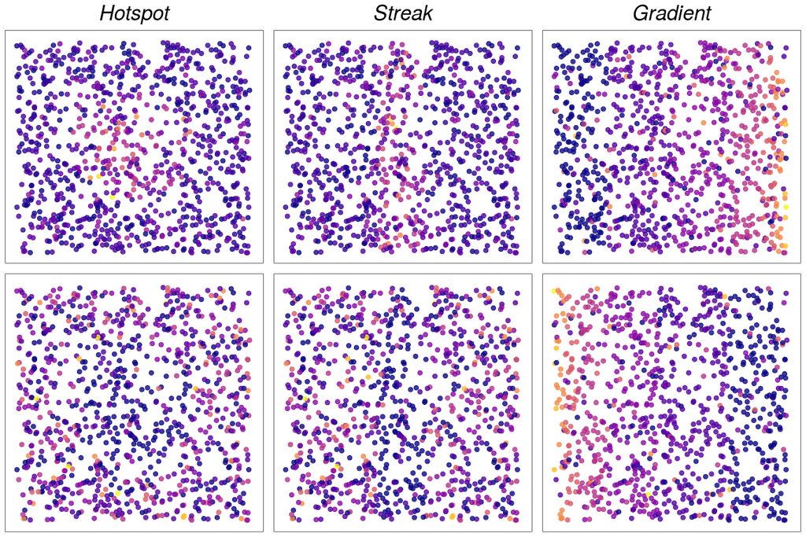

**Power Figures (Fig.1-4): Sample Size Effect**  
Strength = 2, CellProp = 0.2, phi = 0.1. SampleSize varies at 300,1000 and 3000.

> Figure 1: Streak (mu = 1.5)

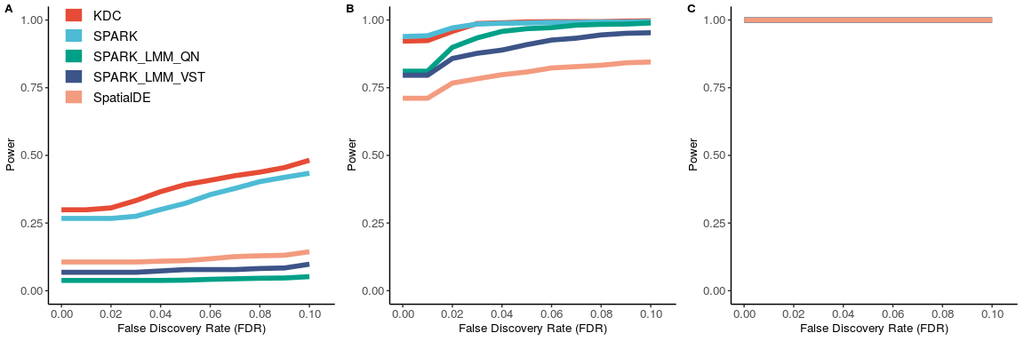

> Figure 2: Hotspot (mu = 1.5)

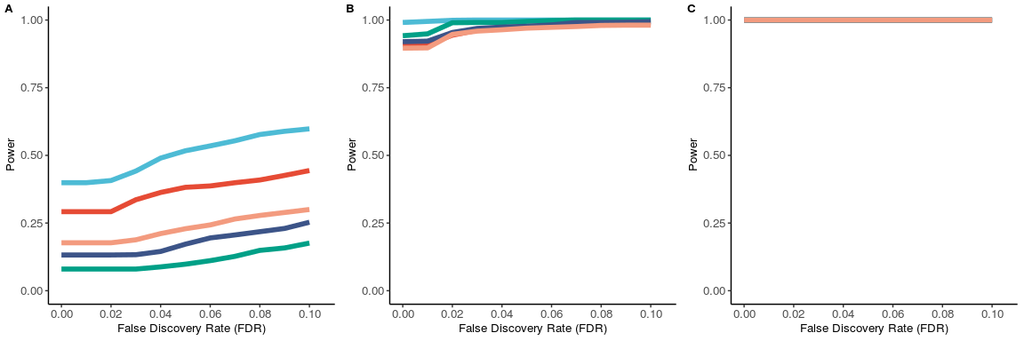

> Figure 3: Streak (mu = 0.5)

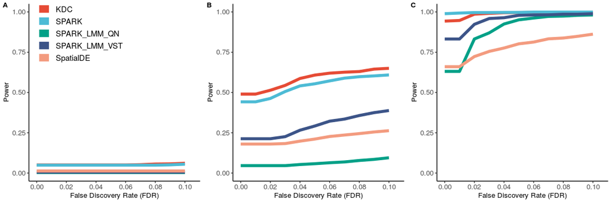

> Figure 4: Hotspot (mu = 0.5)

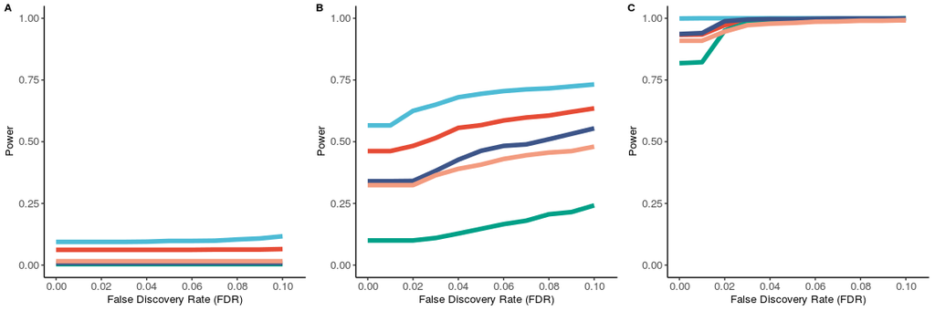

**Power Figures (Fig.5-6): Fraction of Marked Cells Effect**  
SS = 1000, strength = 2, mu = 0.5, phi = 0.1. Fraction of Marked Cells Varies at 0.1, 0.2 and 0.3

> Figure 5: Streak

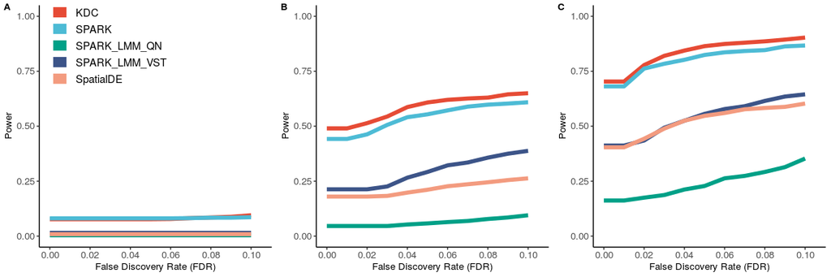

> Figure 6: Hotspot

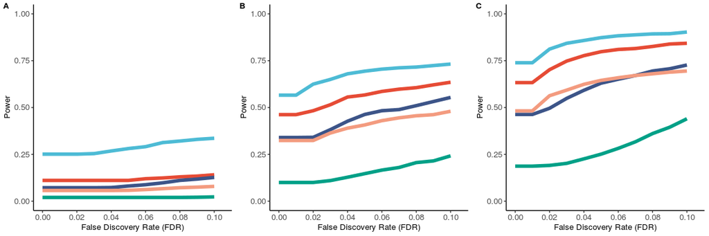

**Power Figures (Fig.7-8): SE Strength Effect**  
SS = 1000, cellProp = 0.2, mu = 0.5, phi = 0.1. SE strength Varies at 1.5, 2 and 3

> Figure 7: Streak

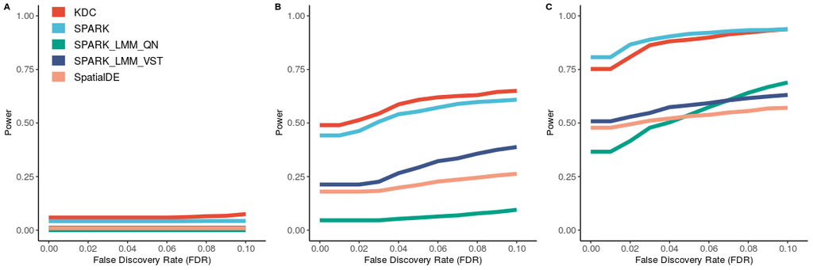

> Figure 8: Hotspot

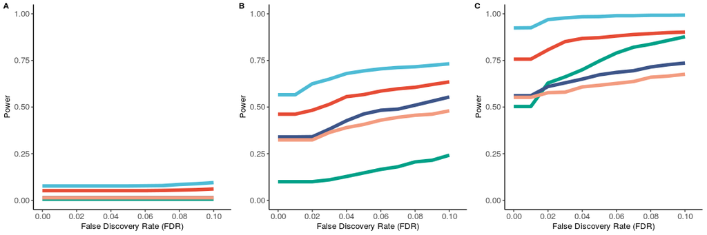

**Power Figures (Fig.9-10): Dispersion Effect**  
SS = 1000, cellProp = 0.2, mu = 0.5, Strength = 2. Phi Varies at 0.1,0.2,1

> Figure 9: Streak

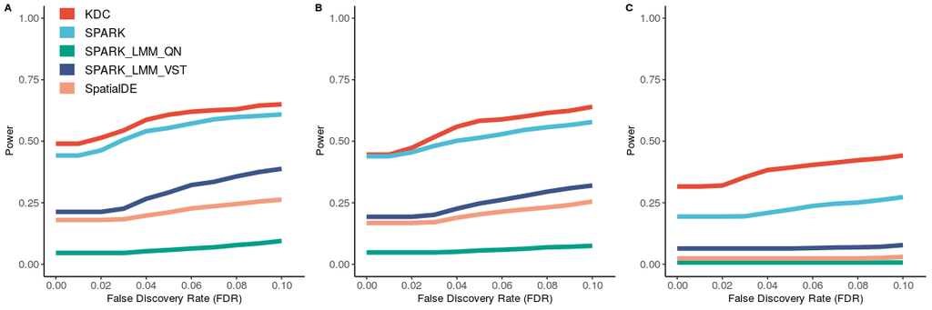

> Figure 10: Hotspot

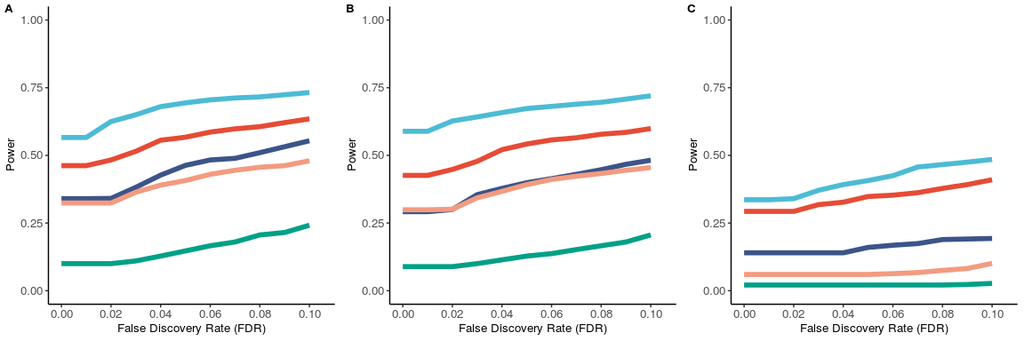

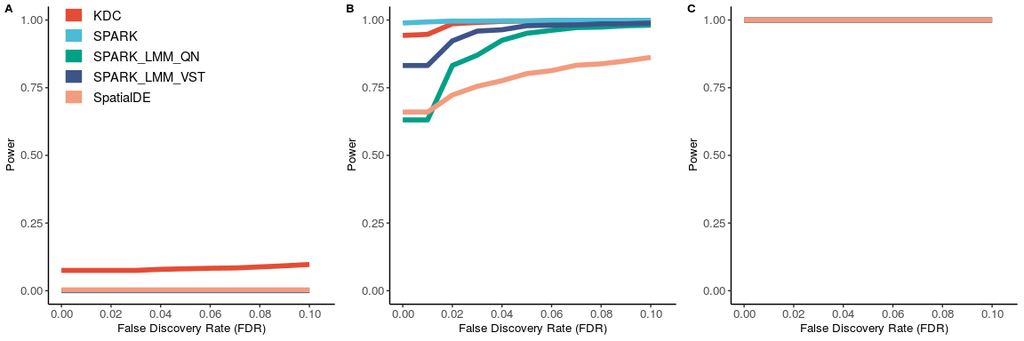

> Figure 12: Hotspot

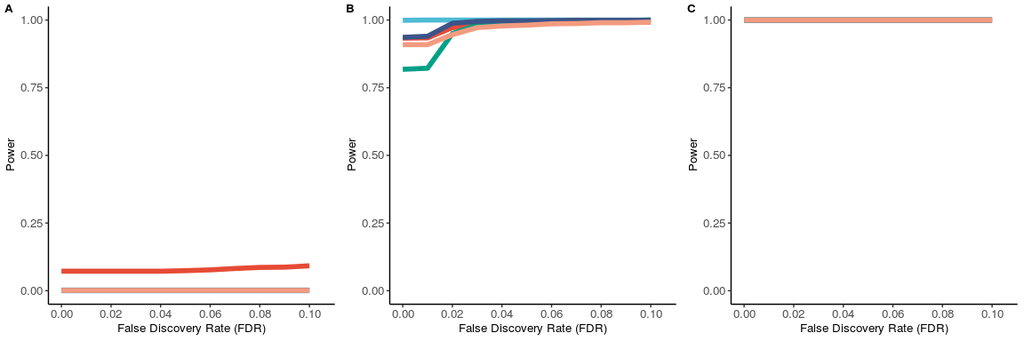